# Mini Project 4 - Report

This document is the report for the Mini Project 4. It has functional specifications for the project.

## Running the code

To run the code, please use the below command from your working directory.

$ python MiniProject4.py

It required SciPy stack and packaged called 'seaborn'. Please see the 'README' file for the specifications.

### Data

Please make sure that the below files are available in the working directory.

BCB-UDJIAD1.csv YALE-SPCOMP.csv presidents_yearly.csv

The files carry all required data. I collected the data sets from the internet or from Quandl. However, I didn't wish to use any internet APIs to collect the data. This is more reliable.

## Code specification

The code is divided into the main function and specific plotting functions.

### Main programme

This just loads and prepares the data.

```python
# Import necessary references
import pandas as pd
import matplotlib.pyplot as plt
import numpy as np
import matplotlib
```

For this report, we firstly load and prepare the data. See the head of SP index levels as an example.

```python
        # load in the data for SP index
        df_sp = pd.read_csv('YALE-SPCOMP.csv', index_col=0, usecols=['Date', 'S&P Composite']).sort_index()
        df_sp.columns = ['sp']
        df_sp.index = pd.to_datetime(df_sp.index).year

        # load data for DJI index
        df_dji = pd.read_csv('BCB-UDJIAD1.csv', index_col=0, usecols=['Date', 'Value']).sort_index()
        df_dji.columns = ['dji']
        df_dji.index = pd.to_datetime(df_dji.index).year

        # move the index levels together
        df_index_level = pd.concat([df_sp, df_dji], axis=1)


        df_sp.head()
```

| Date | sp |
| --- | --- |
| 1919 | 8.92 |
| 1920 | 6.81 |
| 1921 | 7.31 |
| 1922 | 8.78 |
| 1923 | 8.55 |

Next we load in the party and president information.

```python
        # load the party and president data
        df_potus = pd.read_csv('presidents_yearly.csv', index_col=0).sort_index()

        df_potus.head()
```

| Year | President | Party |
| --- | --- | --- |
| 1920 | Harding | Republican |
| 1921 | Harding | Republican |
| 1922 | Harding | Republican |
| 1923 | Coolidge | Republican |
| 1924 | Coolidge | Republican |

We then follow with further manipulations of the data however these are just tranformations to the original data. No further details are commented.

```python
        # calculate the returns for whole index
        df_log_returns = np.log(df_index_level).diff()[1:]

        # move the returns in party/president data together
        df_log_returns_potus_party = pd.concat([df_log_returns, df_potus], axis=1)

        # split the log returns by party
        df_democratic = df_log_returns_potus_party[df_log_returns_potus_party.Party == 'Democratic']
        df_republican = df_log_returns_potus_party[df_log_returns_potus_party.Party == 'Republican']

        # work only with the returns
        df_log_returns_party = pd.concat([df_democratic[['dji', 'sp']], df_republican[['dji', 'sp']]], axis=1)
        # name the new columns
        df_log_returns_party.columns = ['dji_democ', 'sp_democ', 'dji_repub', 'sp_repub']

        # create a data frame for summaries for all returns
        df_summaries = pd.concat([df_democratic[['dji', 'sp']].describe(), df_republican[['dji', 'sp']].describe()], axis=1)
        df_summaries.columns = ['dji_democ', 'sp_democ', 'dji_repub', 'sp_repub']
```

### Describe the original data

I use this method to show the actuall data sets that we work with.

```python
def describe_series(pd_series, set_name):
    """
    Returns descriptive statistics for pandas series object

    :param pd_series: pd.Series object - carries all data
    :param set_name: str - you can use this to set up custom name for plots
    :return: None
    """
    assert isinstance(pd_series, pd.Series), "Pass in a 'pd.Series' object to 'pd_series' variable when calling 'describe_series' function"
    assert isinstance(set_name, str), "Pass in a string variable to 'set_name' parameter when calling 'describe_series' function"

    matplotlib.style.use('ggplot')

    np_series_values = pd_series.values

    line_size = .1
    if len(np_series_values) < 10:
        line_size = .25
    elif len(np_series_values) < 50:
        line_size = .20
    elif len(np_series_values) <= 100:
        line_size = .00125
    elif len(np_series_values) > 900:
        line_size = .0125
    elif len(np_series_values) > 400:
        line_size = .02
    elif len(np_series_values) > 150:
        line_size = .05
    elif len(np_series_values) > 120:
        line_size = .06
    elif len(np_series_values) > 100:
        line_size = .08

    line_size = 0.0005

    fig, axes = plt.subplots(nrows=2, ncols=2, figsize=(15, 10))

    pd_series.plot(ax=axes[0, 0], title='Close price-' + str(set_name),  marker='.', color='r')
    axes[0, 0].tick_params(labelsize=6)
    axes[0, 0].grid(b=True, which='major', color='0.75', linestyle='dotted')

    pd_series.plot(ax=axes[0, 1], kind='hist', title='Histogram-price frequecies- ' + str(set_name))
    pd_series.plot.box(ax=axes[1, 1], vert=False, title='Box Plot - ' + str(set_name))
    pd_series.plot(ax=axes[1, 0], kind='density', title='Empirical propability density - ' + str(set_name),
                   linestyle='-')
    axes[1, 0].vlines(np_series_values.mean(), line_size, 0, color='r', linestyle='dashed', label='Mean')
    axes[1, 0].vlines(np.median(np_series_values), line_size, 0, color='y', linestyle='dashed', label='Median')
    axes[1, 0].vlines(np.median(np_series_values) + np.std(np_series_values), line_size, 0, color='g',
                      linestyle='dashed', label='+Std')
    axes[1, 0].vlines(np.median(np_series_values) - np.std(np_series_values), line_size, 0, color='g',
                      linestyle='dashed', label='-Std')
    axes[1, 0].vlines(np.median(np_series_values) + 2 * np.std(np_series_values), line_size, 0, color='m',
                      linestyle='dotted', label='+2Std')
    axes[1, 0].vlines(np.median(np_series_values) - 2 * np.std(np_series_values), line_size, 0, color='m',
                      linestyle='dotted', label='-2Std')
    axes[1, 0].vlines(np.min(np_series_values), line_size, 0, color='k', linestyle='dashed', label='Min')
    axes[1, 0].vlines(np.max(np_series_values), line_size, 0, color='k', linestyle='dashed', label='Min')
    axes[1, 0].grid(b=True, which='major', color='0.75', linestyle='dotted')
    axes[1, 0].legend(['Close', 'Mean', 'Median', '+1 Std', '-1 Std', '+2 std', '-2 Std', 'Min', 'Max'],
                      loc='best')

    plt.tight_layout()
    plt.show()

    del line_size, np_series_values
    print("\nDescriptive statistics for " + set_name + " are:")
    print(pd_series.describe())
    return None
```

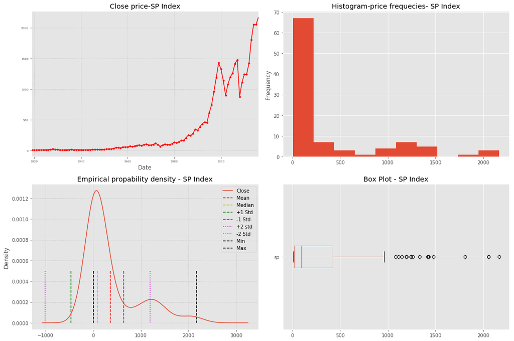

```
Descriptive statistics for SP Index are:
count      98.000000
mean      361.074592
std       554.757696
min         6.810000
25%        15.767500
50%        89.375000
75%       423.857500
max      2164.990000
Name: sp, dtype: float64
```

```python
describe_series(df_sp.sp, 'SP Index')
```

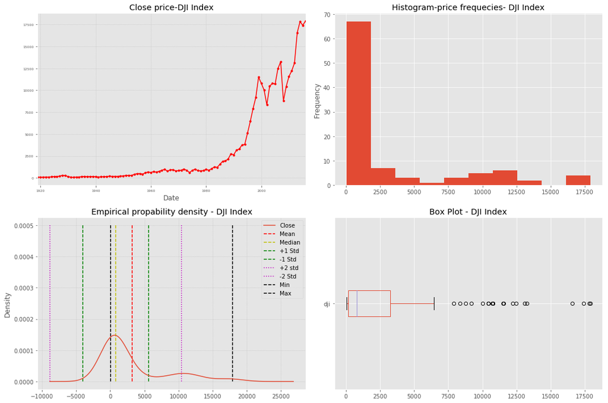

```
Descriptive statistics for DJI Index are:
count       98.000000
mean      3167.274694
std       4848.399210
min         59.930000
25%        180.215000
50%        818.090000
75%       3268.040000
max      17897.460000
Name: dji, dtype: float64
```

```python
describe_series(df_dji.dji, 'DJI Index')
```

### Look at the comparison over the original data set

I prepared the method to visialise the differences between the two stock indices.

```python
def compare_two_series(pd_df_two_series=pd.DataFrame(), set_name=''):
    """
    Prints comparison of two series. Remember to order the the frame by oldest on the top.

    Prints:
        - series over time - log scale and actual
        - returns - log scale and actual
        - cumulative returns - log scale and actual
        - scatter matrix for the series

    :param pd_df_two_series: Data Frame with two time series
    :param set_name: Title for the plots
    :return: None but plots the comparison
    """

    assert isinstance(pd_df_two_series, pd.DataFrame), "Pass in a 'pd.DataFrame' object to 'pd_df_two_series' variable when calling 'compare_two_series' function"
    assert isinstance(set_name, str), "Pass in a string variable to 'set_name' parameter when calling 'describe_series' function"

    matplotlib.style.use('ggplot')

    fig, axes = plt.subplots(nrows=3, ncols=2, figsize=(15, 10))
    pd_df_two_series.plot(ax=axes[0, 0], title='Actual data - ' + set_name)

    np.log(pd_df_two_series).plot(ax=axes[0, 1], title='Actual data on log scale - ' + set_name,)

    df_returns = pd_df_two_series.pct_change()[1:]

    df_returns.plot(ax=axes[1, 0], title='Returns - ' + set_name, marker='.')
    df_returns += 1
    df_returns.cumprod().plot(ax=axes[1, 1], title='Cumulative returns - ' + set_name)

    df_log_returns = np.log(pd_df_two_series).diff()[1:]

    df_log_returns.plot(ax=axes[2, 0], title='Log returns - ' + set_name, marker='.')
    df_log_returns.cumsum().plot(ax=axes[2, 1], title='Log cumulative returns - ' + set_name)

    plt.tight_layout()
    plt.show()

    # create the scatter_matrix
    pd.plotting.scatter_matrix(df_log_returns, alpha=.2, figsize=(6, 6), diagonal='kde')
    plt.suptitle('Scatter matrix for log returns - ' + set_name)
    plt.show()

    return None
```

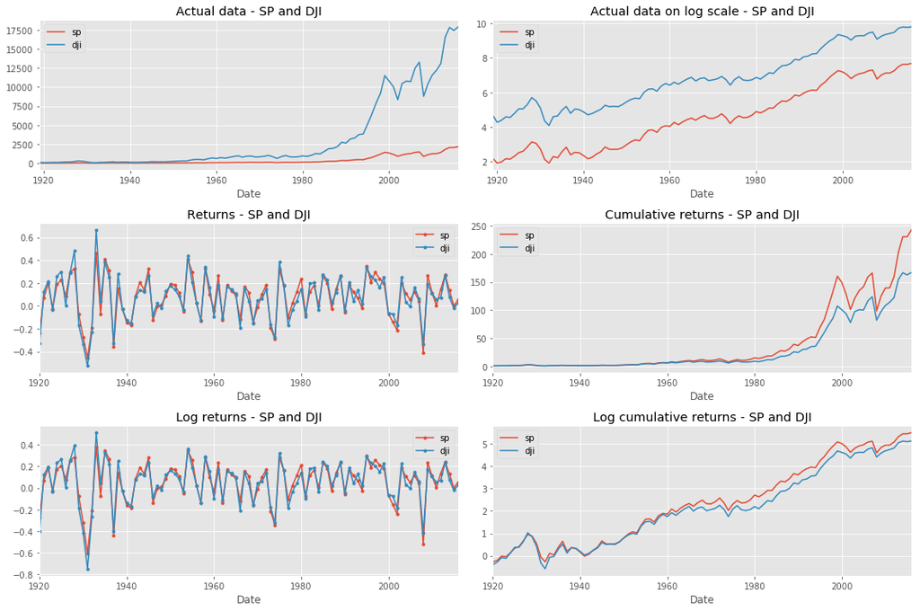

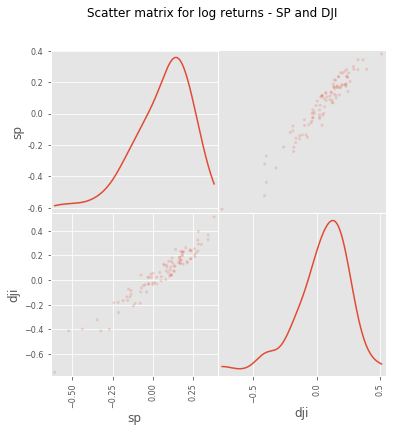

```python
compare_two_series(df_index_level, 'SP and DJI')
```

### Comparison for the returns split by political party

```python
def compare_return_two_sets(pd_df_return_set_1=pd.DataFrame(),
                            pd_df_return_set_2=pd.DataFrame(),
                            set_name=['0', '1']):
    """
    This create 4 plots
        - two scatter matrices using Pandas plotting functionality
        - two distribution comparisons using Seaborn package
    This methods is very Mini Project 4 specific
    It will need tweaking for reuse
    It uses sequential plotting as in Matplotlib

    :param pd_df_return_set_1: pd.DataFrame that carries two columns of returns
    :param pd_df_return_set_2: pd.DataFrame that carries two columns of returns
    :param set_name:
    :return: None but generates plots sequentiallyix
    """

    import seaborn as sns
    matplotlib.style.use('ggplot')

    print("\nThe descriptive statistics for " + set_name[0] + " returns are:\n")
    print(pd_df_return_set_1.describe())

    print("\nThe descriptive statistics for " + set_name[1] + " returns are:\n")
    print(pd_df_return_set_2.describe())

    # create the scatter_matrix
    pd.plotting.scatter_matrix(pd_df_return_set_1, alpha=.2, figsize=(6, 6), diagonal='hist')
    plt.suptitle('Scatter matrix for log returns - ' + set_name[0])
    plt.draw()

    pd.plotting.scatter_matrix(pd_df_return_set_2, alpha=.2, figsize=(6, 6), diagonal='hist')
    plt.suptitle('Scatter matrix for log returns - ' + set_name[1])
    plt.draw()

    matplotlib.style.use('seaborn-dark')

    plt.figure()
    sns.distplot(pd_df_return_set_1[pd_df_return_set_1.columns[0]].values,
                 kde_kws={"label": "dji_democ"},
                 hist_kws={"label": "dji_democ"}
                 )

    sns.distplot(pd_df_return_set_2[pd_df_return_set_2.columns[0]].values,
                 kde_kws={"label": "dji_repub"},
                 hist_kws={"label": "dji_repub"}
                 )
    plt.draw()

    plt.figure()

    sns.distplot(pd_df_return_set_1[pd_df_return_set_1.columns[1]].values,
                 kde_kws={"label": "sp_democ"},
                 hist_kws={"label": "sp_democ"}
                 )

    sns.distplot(pd_df_return_set_2[pd_df_return_set_2.columns[1]].values,
                 kde_kws={"label": "dji_repub"},
                 hist_kws={"label": "dji_repub"}
                 )
    plt.draw()

    plt.show()

    return None
```

```
The descriptive statistics for Democratic returns are:

             dji         sp
count  48.000000  48.000000
mean    0.080529   0.088151
std     0.155812   0.157436
min    -0.397851  -0.437025
25%     0.010499  -0.001727
50%     0.103934   0.113213
75%     0.164655   0.187936
max     0.510992   0.379721

The descriptive statistics for Republican returns are:

             dji         sp
count  49.000000  49.000000
mean    0.025552   0.025727
std     0.230868   0.210624
min    -0.747971  -0.608503
25%    -0.096857  -0.075434
50%     0.047054   0.079425
75%     0.188755   0.172527
max     0.393537   0.342438
```

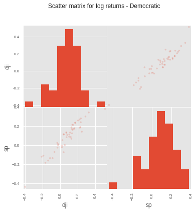

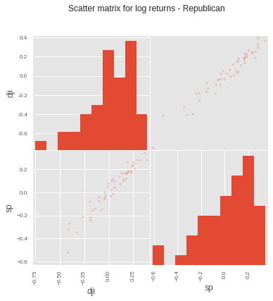

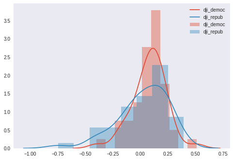

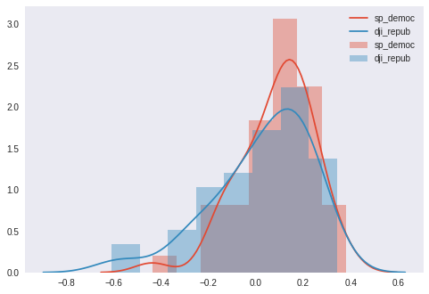

```python
 compare_return_two_sets(df_democratic[['dji', 'sp']], df_republican[['dji', 'sp']], ['Democratic', 'Republican'])
```

In this case we can see that in both cases the returns for the Democratic party have shorter tails than the returns from the time periods when there was a Republican president in the US. Based on these graphs we can see that it is reasonable to expect higher returns during the presidency by a Democratic leader. However, I would not jump to conclusions quickly. This is just based on a small sample and a graph. No statitical testing was done.

### Show the statistical description for the returns

```python
def plot_return_summary(pd_df_summary=pd.DataFrame(), set_name=''):
    """
    Shows bar plot for mean, std, min, 25%, 50%, 75% percentiles and max
    It works with all rows from object that results from pd.DataFrame.describe() method
    It skips first row of this object.

    :param pd_df_summary: pd.DataFrame.describe() object explicitly
    :param set_name: this is just a label
    :return: None but plots the summary
    """

    matplotlib.style.use('ggplot')

    pd_df_summary[1:].plot(legend=True, kind='bar', colormap='Paired')
    plt.title(set_name)
    plt.show()

    return None
```

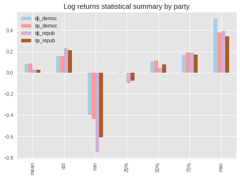

```python
plot_return_summary(df_summaries, 'Log returns statistical summary by party')
```

### Plot the risk and return space

```python
def plot_return_risk(pd_df_summary=pd.DataFrame(), set_name=''):
    """
    This plots median returns in the return/risk space
    It uses pd.DataFrame.describe() object explicitly.
    This is based on the lecture notes - Python II/ Unit 3/ 1/ Sector-wise Performance Comparison

    :param pd_df_summary: pd.DataFrame.describe() object explicitly
    :param set_name: this is just a label
    :return: None but plot the risk/return graph
    """

    matplotlib.style.use('classic')

    g = plt.figure(0)
    plt.xlabel('Standard deviation of log returns')
    plt.ylabel('Median log return')
    plt.title(set_name)
    plt.scatter(pd_df_summary.loc['std'],
                pd_df_summary.loc['50%'],
                marker='*',
                s=500,
                c=range(len(pd_df_summary.ix['std'])),
                )
    for label, x, y in zip(pd_df_summary.columns, pd_df_summary.loc['std'], pd_df_summary.loc['50%']):
        plt.annotate(label,
                     xy=(x, y),
                     xytext=(-20, 20),
                     textcoords='offset points',
                     ha='right',
                     va='bottom',
                     bbox=dict(boxstyle='round,pad=0.5', fc='cornsilk', alpha=0.5),
                     arrowprops=dict(arrowstyle='->', connectionstyle='arc3,rad=0'))
    g.show()
    plt.show()

    return None
```

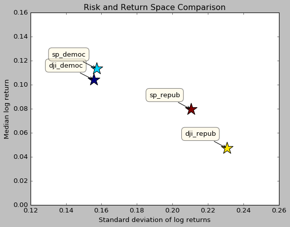

```python
plot_return_risk(df_summaries, 'Risk and Return Space Comparison')
```

This plot is taken from the lecture notes. It shows that the returns during the presidency by a Democratic leader potentially offer higher returns for smaller risk (volatility).

# Summary

This report/project went over some plotting techniques. We have not done any statistical testing. We really should at least test whether the means and standard deviations of the returns are different for each group in a statistical sense. I would not be surprised if the statintacal consideration would tell a different story that that we can read from the graphs.